# Topic Modeling in Python

## 4. Text summarization

Automatic text summarization is the task of producing a concise and fluent summary while preserving key information content and overall meaning in a text document. Text summarization techniques have been developed for the last 60 years and it is a mature subfield of NLP. Recent advances in summarization concentrate on language generation, semantic validation, and hierarchical approaches.

#### Summarization types

Based on the output of the summarization task there are two approaches, extractive and abstractive summarization. The extractive method works by selecting and extracting pieces or sections of a longer text that are more relevant than others. Abstractive approaches attempt to generate new content based on the existing one.

In the image below we can see other types of summarization based on the input, and domain of application.

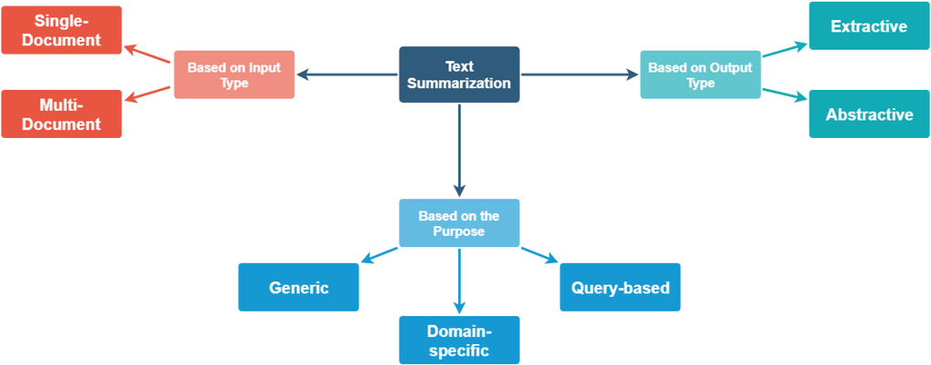

In this tutorial we will concentrate on extractive summarization using PTM.

The basic steps in the summarization pipeline:

1. Construct an intermediate representation of the input text.
2. Score the sentences based on the representation.
3. Select a number of sentences based on a scoring threshold.

#### From topics to summaries

Having presented PTM in Python and the basic concepts behind extractive summarization, how would you utilize PTM to extract relevant phrases from text documents?

Some ideas to consider:

1. Use LDA to obtain topics from documents
2. Use phrases from documents to get the topic that has the highest probability
3. Create a function that selects phrases for each document based on their probability and topic distribution

#### Create your own text summarization algorithm based on LDA

Based on the LDA code examples and the basic steps of text summarization described above, implement your own method for extracting summaries. Select a feature rich corpus, and select a lemmatizer for the language of the corpus. Evaluate different strategies depending on the language, the size of the corpus, and the topic variability.

#### Resources

Monolingual language resources (ACL): https://aclweb.org/aclwiki/List_of_resources_by_language

Multilingual language resources (ACL): https://aclweb.org/aclwiki/Multilingual_Corpora

Document Summarization Python code: https://github.com/g-deoliveira/TextSummarization/blob/master/documentSummaries.py

#### Further reading

Das, D., & Martins, A. F. (2007). A survey on automatic text summarization. Literature Survey for the Language and Statistics II course at CMU, 4(192-195), 57.

Allahyari, M., Pouriyeh, S., Assefi, M., Safaei, S., Trippe, E. D., Gutierrez, J. B., & Kochut, K. (2017). Text summarization techniques: a brief survey. arXiv preprint arXiv:1707.02268.